# TSCI 5050: Introduction to Data Science: Homework 2

Alex F. Bokov

10/31/2017

Thank you for taking this class. I have reviewed this homework and given it a passing grade. Please see my detailed feedback below. In the HTML version it will be highlighted in yellow.

Please copy this file to `YOURNAME_hw02.R` then commit it as usual by issuing the following commands in the bash shell (not in R):

`git co YOURBRANCH`

`git ci YOURNAME_hw02.R -m "Added homework #2"`

`git push`

Repeat the above whenver you make changes to this file. You may work with other people on this homework, just make sure to credit each other on your individual homework sheets.

First we load the `run.R` file using the `source('run.R')` command but we don’t display it in the formatted output to keep it from cluttering up the document.

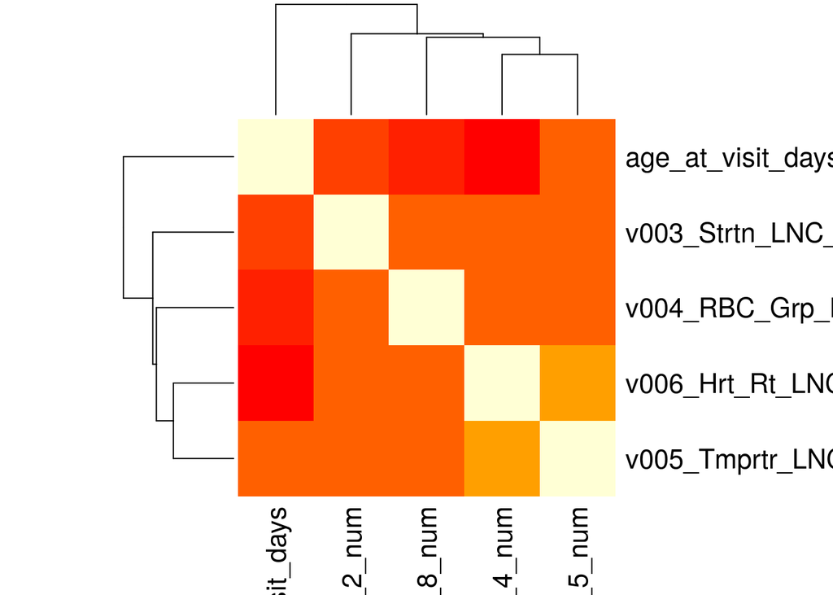

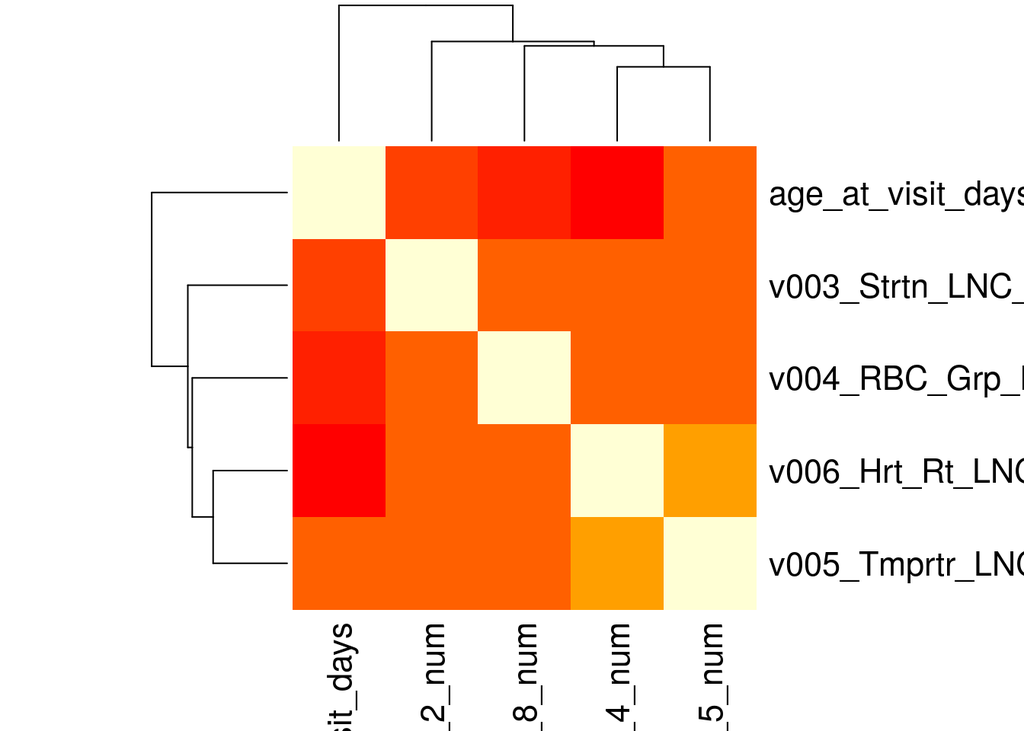

`run.R` already creates a dct01 table, so we just need to add columns